# TAPhelpR_usage

Joe Boyd

2023-12-15

# TAPhelpR

**TAPhelpR** is intended to help prepare to run **TAP** and then evaluate and use the outputs.

Prior to running **TAP**

1. Generating a config file
2. Validating the config file
3. Fetching public data from GEO and ENCODE

After running **TAP**

1. Evaluating completeness of outputs
2. Running suppa2 diffSplice
3. Preparing count matrix for DESeq2 and other analyses
4. Generating UCSC track config files

## Installation

```r
if(!require("devtools")){
  install.packages("devtools")
}
# This optional dependency has fallen out of Bioconductor and must be installed manually.
# It is only required to download data from ENCODE.
devtools::install_github("CharlesJB/ENCODExplorer")
devtools::install_github("FrietzeLabUVM/TAPhelpR")
```

```r
library(TAPhelpR)
library(tidyverse)
```

# Before Running TAP

## Configs

### Generate Config

Configuration files are strongly recommended to run TAP. They can control all command line parameters and also set paths to fastq files. You should also take the opportunity to rename samples to something more meaningful and easier to work with. If you have sequencing replicates, they can be aggregated to single samples in the config.

To use TAPhelpR to generate your config file, you need 2 things. A directory with *reference* files and a directory with *fastq.gz* files.

The *reference* directory should be generated using `setup_scripts/setup_new_reference.sh` from the directory where TAP is installed. This script requires 2 minimal inputs with some additional options. You must provide a single .fasta file and compatible (same organism assembly) gene reference .gtf/.gff file.

The *fastq.gz* files must be gzipped should be for both reads if you have paired-end data. They also must have consistent suffixes (i.e. all end in _R1_001.fastq.gz or _R2_001.fastq.gz for PE data or all end in _R1_001.fastq.gz for SE data). It’s OK if your suffixes differ from these defaults, just be sure you specify f1_suffix (and f2_suffix for PE data) when creating the config file.

```r
# if you're running this code locally, tap_in should be where the honeybee .fastq.gz files
# tap_out should any location you wish to write the pipeline outputs to
tap_in = example_honeybee_input()
tap_out = example_honeybee_output()
```

```r
cfg = config_create(
  inDir = tap_in,
  f1_suffix = "_1.fastq.gz",
  f2_suffix = "_2.fastq.gz",
  outDir = tap_out,
  singularity = "~/lab_shared/scripts/TAP/tap_latest.sif",
  reference = example_honeybee_reference()
)
```

`config_create` only gathers the information required to write the config file. We have the opportunity to add some important information before writing this config.

In our case, `TAPhelpR` provides a metadata file to map SRR accessions to meaningful sample names.

```r
# data.frame from config_create contains fastq file names and default sample name (fastq with suffix removed).
cfg_fq = cfg$fastq_lines
colnames(cfg_fq) = c("file", "srr")
# use merge to add metadata
meta_df = example_honeybee_metadata()
cfg_fq = merge(meta_df, cfg_fq, by = "srr")
cfg_fq = cfg_fq[, c("file", "name")]
# replace fastq data.frame in cfg
cfg$fastq_lines = cfg_fq
```

Now we want to write the config file.

```r
config_write(cfg, "honeybee_config.csv", overwrite = TRUE)
```

```
## [1] "honeybee_config.csv"
```

### Validate Config

Prior to running TAP, it’s a good idea to validate our config file. This validation will not catch all possible errors but focuses on the most common and hardest to diagnose.

```
##                             V1    V2     V3   V4
## SRR3123279_1.fastq.gz honeybee 4days worker rep1
## SRR3123281_1.fastq.gz honeybee 4days worker rep2
## SRR3123372_1.fastq.gz honeybee 4days  queen rep1
## SRR3123380_1.fastq.gz honeybee 4days  queen rep2
```

Note the output of the above is a data.frame with fastq files as the rownames and the _/. delimited name elements split. This also allows you to verify that your names are well formed. Well formed names have the same number of elements. Poorly formed names will make downstream analysis more painful as you’ll constantly have to add additional code to handle these inconsistencies.

You’ll see a warning if sample names are not well formed.

## Fetch Public Data

### ENCODE

You will need the ENCODExplorer package installed.

Fetching data consists of 2 steps. Retrieving file information from ENCODE as a data.frame. This data.frame must then be filtered and used to derive file names. Once this is done, the data.frame is used to fetch or download the specified files.

```r
enc_df = ENCODE_get_file_info(request_organisms = "Homo sapiens", request_target_chipseq = "IKZF1")
```

```
## Results : 258 files, 6 datasets
```

```r
enc_df.fe_bw = subset(enc_df, file_format == "bigWig" & output_type == "fold change over control" & assembly == "GRCh38")
enc_df.fe_bw = dplyr::mutate(
  enc_df.fe_bw,
  rep = ifelse(grepl(";", biological_replicates), "pooled", biological_replicates)
)
DT::datatable(enc_df.fe_bw)
```

|  | accession | file_accession | file_type | file_format | file_size | output_category | output_type | target | investigated_as | nucleic_acid_term | assay | treatment_id | treatment | treatment_amount | treatment_amount_unit | treatment_duration | treatment_duration_unit | treatment_temperature | treatment_temperature_unit | treatment_notes | biosample_id | biosample_type | biosample_name | dataset_biosample_summary | dataset_description | replicate_libraries | replicate_antibody | antibody_target | antibody_characterization | … |
| --- | --- | --- | --- | --- | --- | --- | --- | --- | --- | --- | --- | --- | --- | --- | --- | --- | --- | --- | --- | --- | --- | --- | --- | --- | --- | --- | --- | --- | --- | --- |
| 1 | ENCSR000EUJ | ENCFF111ORU | bigWig | bigWig | 343.6 Mb | signal | fold change over control | IKZF1 | transcription factor | DNA | TF ChIP-seq |  |  |  |  |  |  |  |  |  | /biosamples/ENCBS446GJK/ | cell line | GM12878 | GM12878 | IKZF1 ChIP-seq on human GM12878 | ENCLB639VFZ |  |  |  | … |
| 2 | ENCSR000EUJ | ENCFF361NCG | bigWig | bigWig | 237.1 Mb | signal | fold change over control | IKZF1 | transcription factor | DNA | TF ChIP-seq |  |  |  |  |  |  |  |  |  | /biosamples/ENCBS676TGQ/ | cell line | GM12878 | GM12878 | IKZF1 ChIP-seq on human GM12878 | ENCLB132JED |  |  |  | … |
| 3 | ENCSR000EUJ | ENCFF935KTD | bigWig | bigWig | 513.7 Mb | signal | fold change over control | IKZF1 | transcription factor |  | TF ChIP-seq |  |  |  |  |  |  |  |  |  | /biosamples/ENCBS446GJK/ | cell line | GM12878 | GM12878 | IKZF1 ChIP-seq on human GM12878 | ENCLB639VFZ |  |  |  | … |
| 4 | ENCSR278JQG | ENCFF788XJB | bigWig | bigWig | 1.98 Gb | signal | fold change over control | IKZF1 | transcription factor |  | TF ChIP-seq |  |  |  |  |  |  |  |  |  | /biosamples/ENCBS767MPH/ | cell line | HepG2 | HepG2 | IKZF1 ChIP-seq on human HepG2 | ENCLB786ZXI |  |  |  | … |
| 5 | ENCSR278JQG | ENCFF820CXU | bigWig | bigWig | 1.15 Gb | signal | fold change over control | IKZF1 | transcription factor | DNA | TF ChIP-seq |  |  |  |  |  |  |  |  |  | /biosamples/ENCBS767MPH/ | cell line | HepG2 | HepG2 | IKZF1 ChIP-seq on human HepG2 | ENCLB786ZXI |  |  |  | … |
| 6 | ENCSR278JQG | ENCFF927DYC | bigWig | bigWig | 1.03 Gb | signal | fold change over control | IKZF1 | transcription factor | DNA | TF ChIP-seq |  |  |  |  |  |  |  |  |  | /biosamples/ENCBS803ZJJ/ | cell line | HepG2 | HepG2 | IKZF1 ChIP-seq on human HepG2 | ENCLB396MDN |  |  |  | … |
| 7 | ENCSR395HWC | ENCFF517NJW | bigWig | bigWig | 1.74 Gb | signal | fold change over control | IKZF1 | transcription factor |  | TF ChIP-seq |  |  |  |  |  |  |  |  |  | /biosamples/ENCBS994WPS/ | cell line | K562 | K562 | IKZF1 ChIP-seq on human K562 | ENCLB877SBR |  |  |  | … |
| 8 | ENCSR395HWC | ENCFF166RSX | bigWig | bigWig | 936.5 Mb | signal | fold change over control | IKZF1 | transcription factor | DNA | TF ChIP-seq |  |  |  |  |  |  |  |  |  | /biosamples/ENCBS048GNZ/ | cell line | K562 | K562 | IKZF1 ChIP-seq on human K562 | ENCLB877SBR |  |  |  | … |
| 9 | ENCSR395HWC | ENCFF590UTP | bigWig | bigWig | 905.5 Mb | signal | fold change over control | IKZF1 | transcription factor | DNA | TF ChIP-seq |  |  |  |  |  |  |  |  |  | /biosamples/ENCBS994WPS/ | cell line | K562 | K562 | IKZF1 ChIP-seq on human K562 | ENCLB102PME |  |  |  | … |
| 10 | ENCSR441VHN | ENCFF736LSE | bigWig | bigWig | 1.71 Gb | signal | fold change over control | IKZF1 | transcription factor | DNA | TF ChIP-seq |  |  |  |  |  |  |  |  |  | /biosamples/ENCBS607NAA/ | cell line | GM12878 | GM12878 | IKZF1 ChIP-seq on human GM12878 | ENCLB230GVY |  |  |  | … |

[output cut: 8 more lines]

```r
# you must set file_name on the input data.frame
enc_df.fe_bw = dplyr::mutate(
  enc_df.fe_bw,
  file_name = paste(sep = "_",
                    biosample_name,
                    target,
                    rep,
                    file_accession,
                    "FE.bw"
  )
)
ENCODE_download_files(enc_df.fe_bw)
```

### GEO

Retrieving data from GEO follows the same pattern as getting files from ENCODE except that you start with a valid GEO series accession number, i.e. GSE####.

```r
# you need the GSE accession
gse_df = GEO_get_file_info("GSE152028")
# you typically need to do some cleanup from the title
gse_df = dplyr::mutate(
  gse_df,
  name = sub(" \\+ ", "&", title)
)
gse_df = dplyr::mutate(
  gse_df,
  name = sub(" - ", " ", name)
)
gse_df = dplyr::mutate(
  gse_df,
  name = sub("input_DNA", "input", name)
)
gse_df$name = gsub(" +", "_", gse_df$name)
gse_df$name = paste0(gse_df$name, ".", gse_df$srr)
DT::datatable(gse_df)
```

```r
GEO_download_files(gse_df$srr, fastq_prefixes = gse_df$name, singularity = "tap_latest.sif", bash_or_sbatch = "bash")
```

# After running TAP

## Evaluate completeness

After submitting the TAP pipeline, it’s nice to know how close to completion it is. Once it’s finished, identifying and debugging any errors is also critical. `TAPhelpR` provides a series of *report* functions for this purpose.

`report_completion` is the most basic of these functions. It simply checks for the existence of 3 files that TAP write to record its status.

```r
report_completion(tap_out)
```

```
## 4 samples detected
```

```
## 4 (100%) are no longer in process.
```

```
## 4 (100%) have completed successfully.
```

```
##                                                  name start finish complete
## honeybee_4days_queen_rep1   honeybee_4days_queen_rep1  TRUE   TRUE     TRUE
## honeybee_4days_queen_rep2   honeybee_4days_queen_rep2  TRUE   TRUE     TRUE
## honeybee_4days_worker_rep1 honeybee_4days_worker_rep1  TRUE   TRUE     TRUE
## honeybee_4days_worker_rep2 honeybee_4days_worker_rep2  TRUE   TRUE     TRUE
```

Here we see a message reporting the number of samples that have begun running and: 1) how many are still processing and 2) how many have finished with no errors.

If all samples have finished without error there’s no reason to investigate further.

For a more detailed report of progress, use `report_progress`. You’ll receive a warning if any steps failed to complete due to errors.

```r
report_progress(tap_out)
```

```
##            step honeybee_4days_queen_rep1 honeybee_4days_queen_rep2
## 1:   STAR_align                  complete                  complete
## 2:   bsortindex                  complete                  complete
## 3: salmon_quant                  complete                  complete
## 4:       suppa2                  complete                  complete
## 5:     exactSNP                  complete                  complete
## 6: make_bigwigs                  complete                  complete
##    honeybee_4days_worker_rep1 honeybee_4days_worker_rep2
## 1:                   complete                   complete
## 2:                   complete                   complete
## 3:                   complete                   complete
## 4:                   complete                   complete
## 5:                   complete                   complete
## 6:                   complete                   complete
```

Status plots for a complete run look like this:

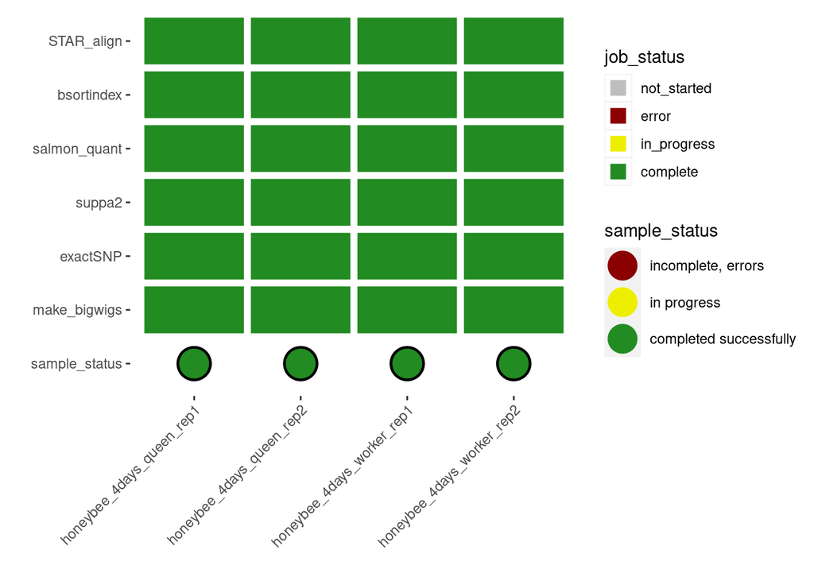

```r
report_progress_plot(tap_out)
```

If there are errors or jobs still in progress you’ll see something like this:

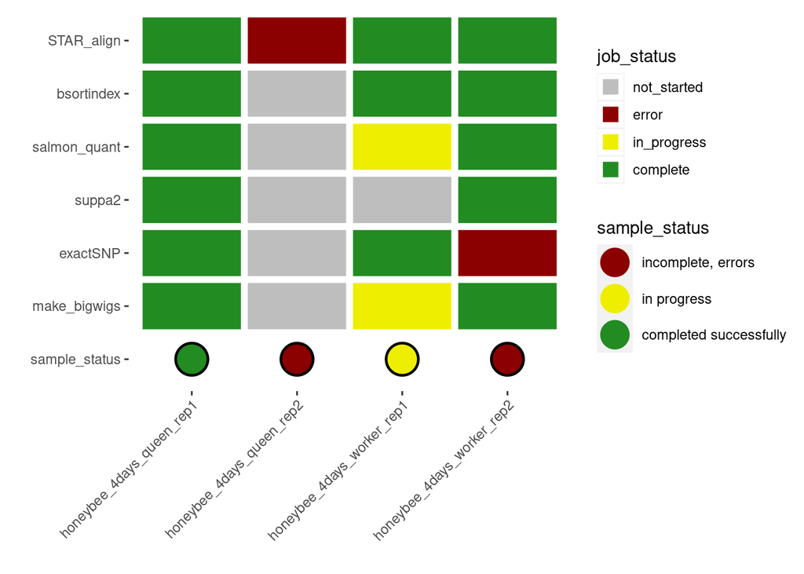

```r
report_progress_plot(example_honeybee_output.in_progress())
```

Finally, if there were errors, use `report_errors`.

```r
report_errors(tap_out)
```

This will return paths to all of the relevant .error log files. You’ll need to investigate these files to diagnose and resolve the errors. You may need to delete affected files but then you can resubmit TAP using the same output. You must allow TAP to finish running or cancel remaining jobs before resubmitting.

## Working with outputs

TAPhelpR contains several setup_*_files functions to create a convenient data.frame containing file paths and meta data.

```r
bam_files = setup_bam_files(tap_out, variable_map = c("species", "day", "role", "rep"))
```

The generic equivalent of the above looks like this:

```r
setup_files(tap_out, pattern = "sortedByCoord.out.bam$", variable_map = c("species", "day", "role", "rep"))
```

```
##                                                                                                                                                   file
## 1:  /slipstream_old/home/joeboyd/R_workspace.combined/TAPhelpR.data/honeybee_TAP_output.rename/honeybee_4days_queen_rep1.Aligned.sortedByCoord.out.bam
## 2:  /slipstream_old/home/joeboyd/R_workspace.combined/TAPhelpR.data/honeybee_TAP_output.rename/honeybee_4days_queen_rep2.Aligned.sortedByCoord.out.bam
## 3: /slipstream_old/home/joeboyd/R_workspace.combined/TAPhelpR.data/honeybee_TAP_output.rename/honeybee_4days_worker_rep1.Aligned.sortedByCoord.out.bam
## 4: /slipstream_old/home/joeboyd/R_workspace.combined/TAPhelpR.data/honeybee_TAP_output.rename/honeybee_4days_worker_rep2.Aligned.sortedByCoord.out.bam
##     species   day   role  rep                       name
## 1: honeybee 4days  queen rep1  honeybee_4days_queen_rep1
## 2: honeybee 4days  queen rep2  honeybee_4days_queen_rep2
## 3: honeybee 4days worker rep1 honeybee_4days_worker_rep1
## 4: honeybee 4days worker rep2 honeybee_4days_worker_rep2
```

## Run suppa2 diffSplice

```r
suppa_joinFiles(bam_files, by = "role")
```

```r
suppa_diffSplice(
  ref_location = example_honeybee_reference(),
  PSI_todo = TAP_SPLICE_EVENTS$SkippingExon)
```

```r
suppa_diffSplice.within_group(
  input_files = bam_files,
  within_group = "day",
  between_group = "role",
  ref_location = example_honeybee_reference(),
  PSI_todo = TAP_SPLICE_EVENTS$SkippingExon)
```

```r
suppa_clusterEvents(PSI_todo = TAP_SPLICE_EVENTS$SkippingExon)
```

## Counts and DESeq2

```r
mat = load_counts(tap_out)
head(mat)
```

```
##           honeybee_4days_queen_rep1 honeybee_4days_queen_rep2
## LOC551580                       281                       396
## LOC551555                      3346                      3664
## LOC726347                        43                        81
## Rfwd3                           296                       320
## LOC726145                      1763                      1825
## LOC551448                      1101                      1256
##           honeybee_4days_worker_rep1 honeybee_4days_worker_rep2
## LOC551580                        218                        213
## LOC551555                       2599                       2126
## LOC726347                         56                         59
## Rfwd3                            215                        185
## LOC726145                       1673                       1484
## LOC551448                        939                        674
```

```r
#if you supply the reference gtf file, or GRanges of same, to load_counts, gene_ids in counts will be aggregated to gene_name
mat.gene_name = load_counts(tap_out, gtf_file = file.path(example_honeybee_reference(), "GTF/current.gtf"), name_attribute = "gene")
```

```r
library(DESeq2)
meta_df = bam_files
meta_df$file = NULL
meta_df = dplyr::mutate(meta_df, name = paste(species, day, role, rep, sep = "_"))
des = DESeqDataSetFromMatrix(mat[, meta_df$name], colData = meta_df, design = ~role)
# and run from there ...
```

## UCSC tracks

```r
stage_output_for_UCSC_tracks(tap_out, track_hosting_dir = "~/public_files/honeybee", overwrite = TRUE)
"~/public_files/honeybee" %>%
  dir(full.names = TRUE) %>%
  dir(full.names = TRUE) %>%
  sample(size = 6)
```

```
## [1] "/slipstream/home/joeboyd/public_files/honeybee/raw_positive/6d_queen_A.Aligned.sortedByCoord.out_raw_positive.bw"
## [2] "/slipstream/home/joeboyd/public_files/honeybee/normalized_unstranded/6d_worker_A.Aligned.sortedByCoord.out_normalized_unstranded.bw"
## [3] "/slipstream/home/joeboyd/public_files/honeybee/normalized_positive_showSplice/honeybee_4days_worker_rep1.Aligned.sortedByCoord.out_normalized_positive.showSplice.bw"
## [4] "/slipstream/home/joeboyd/public_files/honeybee/raw_unstranded_showSplice/honeybee_4days_worker_rep2.Aligned.sortedByCoord.out_raw_unstranded.showSplice.bw"
## [5] "/slipstream/home/joeboyd/public_files/honeybee/raw_unstranded_showSplice/6d_worker_B.Aligned.sortedByCoord.out_raw_unstranded.showSplice.bw"
## [6] "/slipstream/home/joeboyd/public_files/honeybee/raw_positive/6d_worker_B.Aligned.sortedByCoord.out_raw_positive.bw"
```

launch shiny app

```r
launch_UCSC_tracks_app.UVM_galaxy(track_hosting_dir = "~/public_files/honeybee")
```